# Basic Hypothesis Testing

MPA 6020 (Spring 2016)

2016-03-13

# Testing Sample Proportions

Say you are flipping a fair coin twice. You know you can end up with Heads or Tails on any given toss. The sample space would then be $S = \left\{ HH, HT, TH, TT \right\}$, i.e., the sample size is $n=4$. The probability of getting exactly one Tails is $\dfrac{2}{4} = 0.5$ and so is the probability of one Heads. What if we flipped the coin ten times? What would be the probability of exactly three Tails in ten flips of the coin? We could spell out the full sample space and then calculate the needed probability but that would be tedious. It would be easier to use a formula that does this calculation for us.

$$\begin{align}
P\left[X \text{ successes}\right] = \binom{n}{X}p^{X}\left(1 - p\right)^{n-X} \\
& \text{where } \binom{n}{x} = \dfrac{n!}{X!(n-X)!} \text{ and } \\
& n! = n \times (n-1) \times (n-2) \times \cdots \times 2 \times 1
\end{align}$$

Let us define Success as a Tails resulting on the flip, and X being 3 Tails in ten flips of the coin (i.e., $n=10$). Let us also assume that it is a fair coin so that the probability of Tails on any single flip of the coin is $p=0.5$. Plugging these values into the equation will yield:

$$\begin{align}
P\left[3 \text{ successes}\right] = \binom{10}{3}0.5^{3}\left(1 - 0.5 \right)^{10-3} \\
& = \dfrac{10 \times 9 \times 8 \times \cdots \times 1}{\left(3 \times 2 \times 1 \right) \left(7 \times 6 \times \cdots \times 1 \right)} \left(0.5 \right)^{3} \left(0.5 \right)^{7} \\
& = \dfrac{10 \times 9 \times 8 }{\left(3 \times 2 \times 1 \right)} \left(0.5 \right)^{3} \left(0.5 \right)^{7} \\
& = \left(10 \times 3 \times 4 \right)\left(0.5 \right)^{3} \left(0.5 \right)^{7} \\
& = \left(120\right) \left(0.125 \right) \left(0.0078125 \right) \\
& = 0.1171875
\end{align}$$

Using R as a calculator we could solve the above formula as follows:

```r
n = 10
x = 3
p = 0.5
p.3tails = choose(n, x) * (p)^(x) * (1 - p)^{
    n - x
}
p.3tails
```

```
## [1] 0.1171875
```

What about three or more Tails? We could calculate the the probability of exactly three Tails, four Tails, and so on through ten Tails, add these up, and we would have our answer … all using the formula above. An R function, `rbinom()`, can do these calculations for us quite easily. Below we do so for the example above.

```r
set.seed(13579)
n = 1e+07
x = rbinom(n, 10, p = 0.5)
tab.x = table(x)
tab.x
```

| 0 | 1 | 2 | 3 | 4 | 5 | 6 | 7 | 8 | 9 | 10 |
| --- | --- | --- | --- | --- | --- | --- | --- | --- | --- | --- |
| 9736 | 97255 | 438778 | 1169791 | 2051968 | 2462822 | 2050665 | 1171457 | 439391 | 98260 | 9877 |

```r
ptab.x = (tab.x/n)
ptab.x
```

| 0 | 1 | 2 | 3 | 4 | 5 | 6 | 7 | 8 | 9 | 10 |
| --- | --- | --- | --- | --- | --- | --- | --- | --- | --- | --- |
| 0.0009736 | 0.0097255 | 0.0438778 | 0.1169791 | 0.2051968 | 0.2462822 | 0.2050665 | 0.1171457 | 0.0439391 | 0.009826 | 0.0009877 |

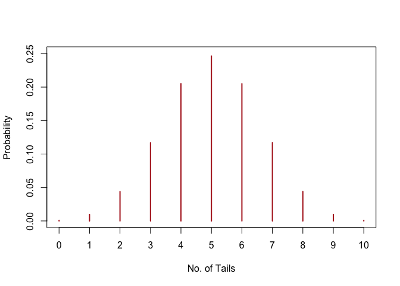

```r
plot(ptab.x, ylab = "Probability", xlab = "No. of Tails", xlim = c(0,
    10), ylim = c(0, 0.25), col = "firebrick")
```

Note: If it is a fair coin then half the flips result in Tails … this is the most likely outcome. Say you flip the coin 10 times and you end up with only 1 Tails. Could this by chance? Sure, because we can see that this could happen with some non-zero probability, just as we could also end up with no Tails or even with ten Tails! Strange outcomes can result, even if they occur very rarely, and by chance alone. As a result, we have to generate some rules that can guide us in determining when to suspect that something is wrong because of an unusual result and when to determine that the result isn’t very unusual after all.

## The Binomial Test

Standard Error: $SE_{\hat{p}} = \sqrt{\dfrac{\hat{p}\left(1-\hat{p} \right)}{n-1}}$

For the Agresti-Coull confidence interval:  
First calculate $p^{'} = \dfrac{X+2}{n+4}$  
CI is then given by: $p^{'} - z\sqrt{ \dfrac{p^{'} \left(1-p^{'} \right) } {n+4} } < p < p^{'} + z\sqrt{ \dfrac{p^{'} \left(1-p^{'} \right) } {n+4} }$

Alternatively, use the `binom` library as shown below:

```r
library(binom)
# binom.test(x, n, p=?, alternative='?', conf.level=?)
# binom.confint(x, n, p=?, alternative='?', conf.level=?,
# methods = 'ac')
```

### An Example

In 1955, John Wayne played Genghis Khan in *The Conqueror*. The movie was filmed downwind from a site where 11 overground nuclear bomb tests had been conducted. Of the 220 crew on the movie, 91 ended up being diagnosed with cancer by the early 1980s. Population data record that only about 14% of people in the same age-group as the movie crew should, on average, have been diagnosed with cancer within the same time frame of exposure.

1. What is the best estimate of the probability of a member of the crew getting cancer within the study interval?

```r
n = 220
x = 91
p.sample = x/n
p.sample
```

```
## [1] 0.4136364
```

The best estimate is `0.4136364`

2. Test whether the cancer rate for the movie crew was different from that for the population. Use $\alpha = 0.05$ and calculate the Agresti-Coull confidence interval.

H0: The cancer rate for the movie crew is the same as that of the population (p = 0.14)  
HA: The cancer rate for the movie crew is NOT the same as that of the population (p is not equal to 0.14)

```r
library(binom)
binom.test(x, n, p = 0.14, alternative = "two.sided", conf.level = 0.95)
```

```
##
##  Exact binomial test
##
## data:  x and n
## number of successes = 91, number of trials = 220, p-value <
## 2.2e-16
## alternative hypothesis: true probability of success is not equal to 0.14
## 95 percent confidence interval:
##  0.3478469 0.4817857
## sample estimates:
## probability of success
##              0.4136364
```

```r
binom.confint(x, n, p = 0.14, alternative = "two.sided", conf.level = 0.95,
    methods = "ac")
```

| method | x | n | mean | lower | upper |
| --- | --- | --- | --- | --- | --- |
| agresti-coull | 91 | 220 | 0.4136364 | 0.3505683 | 0.4796687 |

The P-value is practically 0 so we can easily reject the null hypothesis (H0). The data suggest that the cancer rate for the movie crew was different from that of the population.

## Another Example: The Titanic

```r
library(titanic)
data(titanic_train)  # load data from titanic package
df = titanic_train  # save it as df
names(df)  # see variables in the data-set
```

```
##  [1] "PassengerId" "Survived"    "Pclass"      "Name"        "Sex"
##  [6] "Age"         "SibSp"       "Parch"       "Ticket"      "Fare"
## [11] "Cabin"       "Embarked"
```

**VARIABLE DESCRIPTIONS:**

- Survived Survival (0 = No; 1 = Yes)
- Pclass Passenger Class (1 = 1st; 2 = 2nd; 3 = 3rd)
- Name Name
- Sex Sex
- Age Age
- SibSp Number of Siblings/Spouses Aboard
- Parch Number of Parents/Children Aboard
- Ticket Ticket Number
- Fare Passenger Fare
- Cabin Cabin
- Embarked Port of Embarkation (C = Cherbourg; Q = Queenstown; S = Southampton)

SPECIAL NOTES:

Pclass is a proxy for socio-economic status (SES) – 1st ~ Upper; 2nd ~ Middle; 3rd ~ Lower

Age is in Years – Fractional if Age less than One (1). If the Age is Estimated, it is in the form xx.5

With respect to the family relation variables (i.e. sibsp and parch) some relations were ignored. The following are the definitions used for sibsp and parch.

- Sibling: Brother, Sister, Stepbrother, or Stepsister of Passenger Aboard Titanic
- Spouse: Husband or Wife of Passenger Aboard Titanic (Mistresses and Fiances Ignored)
- Parent: Mother or Father of Passenger Aboard Titanic
- Child: Son, Daughter, Stepson, or Stepdaughter of Passenger Aboard Titanic

Other family relatives excluded from this study include cousins, nephews/nieces, aunts/uncles, and in-laws. Some children travelled only with a nanny, therefore parch=0 for them. As well, some travelled with very close friends or neighbors in a village, however, the definitions do not support such relations.

Let us clean it up a bit by labeling `Survived`, `Pclass` and the port of embarkation `(Embarked)` as follows:

```r
df$Survived = factor(df$Survived, levels = c(0, 1), labels = c("Died",
    "Survived"))
df$Pclass = factor(df$Pclass, levels = c(1, 2, 3), labels = c("1st Class",
    "2nd Class", "3rd Class"))
df$Embarked = factor(df$Embarked, labels = c(NA, "Cherbourg",
    "Queenstown", "Southampton"))
```